# Final Project

Hunter Garrison, Kevin Smith, Reese Madsen, Giulio Martini

2024-04-26

# Section 1: Introduction

In this project, we are working with a dataset observing the prices of houses and corresponding attributes of each house in India. Below are the attributes of each house recorded in the dataset:

| Attribute | Description | Data Type |
| --- | --- | --- |
| **price** | Price of the houses in rupees. | Integer |
| area | Area of a house in square feet | Integer |
| bedrooms | Number of bedrooms in house | Integer |
| bathrooms | Number of bathrooms in house | Integer |
| stories | Number of stories in house | Integer |
| mainroad | Whether or not house is connected to main road | Boolean |
| guestroom | Whether or not house has a guest room | Boolean |
| basement | Whether or not house has a basement | Boolean |
| hotwaterheating | Whether or not house has a hot-water heater | Boolean |
| airconditioning | Whether or not house has air conditioning | Boolean |
| parking | Number of parking spots at house | Integer |
| prefarea | Whether or not the house is in a preferred area | Boolean |
| furnishingstatus | Furnishing status of the house | String |

Below is the first 5 lines of our dataset:

|  | price | area | bedrooms | bathrooms | stories | mainroad | guestroom | basement | hotwaterheating | airconditioning | parking | prefarea | furnishingstatus |
| --- | --- | --- | --- | --- | --- | --- | --- | --- | --- | --- | --- | --- | --- |
| 1 | 13300000 | 7420 | 4 | 2 | 3 | yes | no | no | no | yes | 2 | yes | furnished |
| 2 | 12250000 | 8960 | 4 | 4 | 4 | yes | no | no | no | yes | 3 | no | furnished |
| 3 | 12250000 | 9960 | 3 | 2 | 2 | yes | no | yes | no | no | 2 | yes | semi-furnished |
| 4 | 12215000 | 7500 | 4 | 2 | 2 | yes | no | yes | no | yes | 3 | yes | furnished |
| 5 | 11410000 | 7420 | 4 | 1 | 2 | yes | yes | yes | no | yes | 2 | no | furnished |

We are attempting to create a linear regression model that best explains the variance in the price of the houses using the predictors in our dataset. In this report, we will explore our data by finding collinearity, outliers, influential points, and by checking error assumption violations. We will also discover which variables are the most important by using model selection, and test OLS as well as GLS and WLS regressions.

Model diagnostics (error assumptions/outliers/influential points): Kevin

Variable Selection (forward/backward/step/AIC/BIC/RMSE_LOOCV): Hunter

Collinearity/GLS/WLS: Reese

Categorical Predictors (Interacitve/additive models): Guilio

### Collinearity

In our study of the dataset we must ask ourselves whether or not the data is plagued by the issue of collinearity: do the predictors present a linear relationship, not just with the response, but within each other as well? Collinearity can be deleterious when inspecting a model and deciphering its interpretation; inflated R^2 scores and diminished p-values are but a few of the problems that arise alongside predictor collinearity, as such, the dataset must be tested for it.

Let us begin by obtaining once more an overview of the dataset: what each predictor is composed of, and the data type it is made up of.

```r
str(data)
```

```
## 'data.frame':    545 obs. of  13 variables:
##  $ price           : int  13300000 12250000 12250000 12215000 11410000 10850000 10150000 10150000 9870000 9800000 ...
##  $ area            : int  7420 8960 9960 7500 7420 7500 8580 16200 8100 5750 ...
##  $ bedrooms        : int  4 4 3 4 4 3 4 5 4 3 ...
##  $ bathrooms       : int  2 4 2 2 1 3 3 3 1 2 ...
##  $ stories         : int  3 4 2 2 2 1 4 2 2 4 ...
##  $ mainroad        : chr  "yes" "yes" "yes" "yes" ...
##  $ guestroom       : chr  "no" "no" "no" "no" ...
##  $ basement        : chr  "no" "no" "yes" "yes" ...
##  $ hotwaterheating : chr  "no" "no" "no" "no" ...
##  $ airconditioning : chr  "yes" "yes" "no" "yes" ...
##  $ parking         : int  2 3 2 3 2 2 2 0 2 1 ...
##  $ prefarea        : chr  "yes" "no" "yes" "yes" ...
##  $ furnishingstatus: chr  "furnished" "furnished" "semi-furnished" "furnished" ...
```

The next part concerns the creation of a *correlation matrix* and *correlation heatmap* between each numerical predictor. This measures the correlation between predictors, and provides us with a visual method of estimating it. Each categorical column is *label encoded* - their class value is turned to a constant integer - and is added to the correlation matrix.

```r
library(dplyr)
```

```r
library(corrplot)
library(forcats)

data <- data %>%
  mutate(across(where(is.character), as.factor))

data_encoded <- data %>%
  mutate(across(where(~is.factor(.) && nlevels(.) <= 3), as.integer))

data_numeric_only <- data_encoded %>%
  select(where(is.numeric))

housing_preds <- select(data_numeric_only, -price)

cor_matrix <- cor(housing_preds, use = "complete.obs")
rounded_cor_matrix <- round(cor_matrix, 3)

print(rounded_cor_matrix)
```

```
##                    area bedrooms bathrooms stories mainroad guestroom basement
## area              1.000    0.152     0.194   0.084    0.289     0.140    0.047
## bedrooms          0.152    1.000     0.374   0.409   -0.012     0.081    0.097
## bathrooms         0.194    0.374     1.000   0.326    0.042     0.126    0.102
## stories           0.084    0.409     0.326   1.000    0.122     0.044   -0.172
## mainroad          0.289   -0.012     0.042   0.122    1.000     0.092    0.044
## guestroom         0.140    0.081     0.126   0.044    0.092     1.000    0.372
## basement          0.047    0.097     0.102  -0.172    0.044     0.372    1.000
## hotwaterheating  -0.009    0.046     0.067   0.019   -0.012    -0.010    0.004
## airconditioning   0.222    0.161     0.187   0.294    0.105     0.138    0.047
## parking           0.353    0.139     0.177   0.046    0.204     0.037    0.051
## prefarea          0.235    0.079     0.063   0.044    0.200     0.161    0.228
## furnishingstatus -0.171   -0.123    -0.144  -0.105   -0.157    -0.118   -0.113
##                  hotwaterheating airconditioning parking prefarea
## area                      -0.009           0.222   0.353    0.235
## bedrooms                   0.046           0.161   0.139    0.079
## bathrooms                  0.067           0.187   0.177    0.063
## stories                    0.019           0.294   0.046    0.044
## mainroad                  -0.012           0.105   0.204    0.200
## guestroom                 -0.010           0.138   0.037    0.161
## basement                   0.004           0.047   0.051    0.228
## hotwaterheating            1.000          -0.130   0.068   -0.059
## airconditioning           -0.130           1.000   0.159    0.117
## parking                    0.068           0.159   1.000    0.092
## prefarea                  -0.059           0.117   0.092    1.000
## furnishingstatus          -0.032          -0.150  -0.178   -0.108
##                  furnishingstatus
## area                       -0.171
## bedrooms                   -0.123
## bathrooms                  -0.144
## stories                    -0.105
## mainroad                   -0.157
## guestroom                  -0.118
## basement                   -0.113
## hotwaterheating            -0.032
## airconditioning            -0.150
## parking                    -0.178
## prefarea                   -0.108
## furnishingstatus            1.000
```

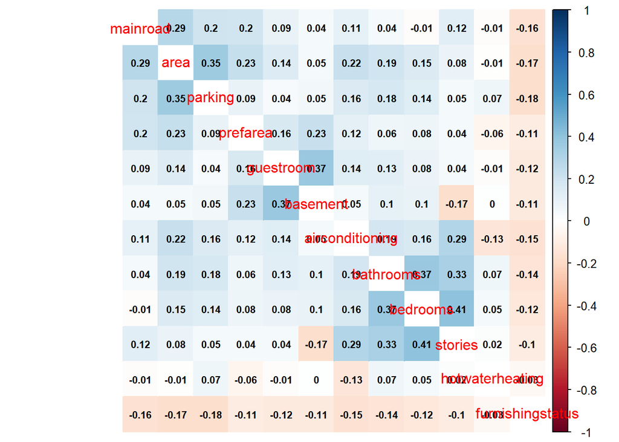

```r
cor_matrix <- cor(housing_preds, use = "complete.obs")

corrplot(cor_matrix, method = 'color', order = 'hclust',  diag = FALSE,
         number.cex = 0.7, addCoef.col = 'black', tl.pos = 'd', cl.pos = 'r')
```

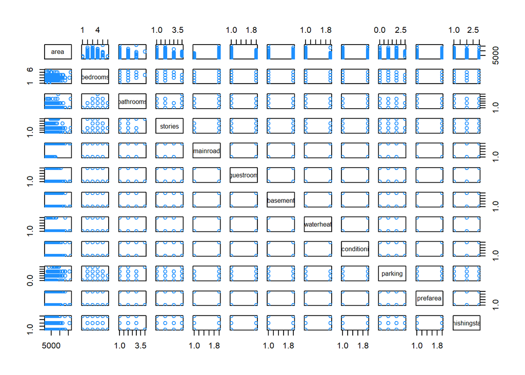

```r
pairs(housing_preds, col = 'dodgerblue', pch=1)
```

```r
library(olsrr)
model = lm(price ~ ., data = data_encoded)

round(ols_eigen_cindex(model)[, 1:2], 4)
```

| Eigenvalue | Condition Index |
| --- | --- |
| 11.4591 | 1.0000 |
| 0.5846 | 4.4275 |
| 0.2140 | 7.3182 |
| 0.1537 | 8.6333 |
| 0.1229 | 9.6550 |
| 0.1016 | 10.6223 |
| 0.0886 | 11.3721 |
| 0.0778 | 12.1358 |
| 0.0622 | 13.5738 |
| 0.0569 | 14.1939 |

[output cut: 3 more lines]

The next step is viewing the dataset’s condition numbers, based on a linear model’s (that is using the dataset) values. The condition number appears to be a small 14.1939. Usually, a value above 30 marks the dataset for collinearity. The correlation with such a low condition number suggests that this is not an issue. To further confirm this hypothesis, we shall check each predictor’s VIF value.

```r
library(faraway)
vif(model)
```

```
##             area         bedrooms        bathrooms          stories
##         1.325208         1.367503         1.286559         1.478029
##         mainroad        guestroom         basement  hotwaterheating
##         1.172661         1.212687         1.320749         1.039293
##  airconditioning          parking         prefarea furnishingstatus
##         1.207262         1.211959         1.148598         1.095641
```

Only predictors with VIFs above 5 are considered problematic, however we can see that, in this dataset, the highest VIF value is 1.478029. We could stop, however we wish to make the investigation very thorough.

We can then check if the variables are orthogonal. An orthogonal variable is not plagued by multicollinearity, and has a R^2_k of less than 0.3, their formula is presented above, along with the results.

```r
1 - 1/vif(model)
```

```
##             area         bedrooms        bathrooms          stories
##       0.24540168       0.26874003       0.22273304       0.32342322
##         mainroad        guestroom         basement  hotwaterheating
##       0.14723849       0.17538517       0.24285414       0.03780781
##  airconditioning          parking         prefarea furnishingstatus
##       0.17167947       0.17488936       0.12937340       0.08729247
```

We can see that most predictors are orthogonal, with the exception of *stories*.

If, perchance, there was an issue of collinearity, we could check the individual condition numbers. They would have to be above 30. Each value above 30 would signify a singular instance of a problematic linear dependence between predictors. Luckily, there is none here, as you can see from the values below.

```r
library(olsrr)

round(ols_eigen_cindex(model), 3)
```

| Eigenvalue | Condition Index | intercept | area | bedrooms | bathrooms | stories | mainroad | guestroom | basement | hotwaterheating | airconditioning | parking | prefarea | furnishingstatus |
| --- | --- | --- | --- | --- | --- | --- | --- | --- | --- | --- | --- | --- | --- | --- |
| 11.459 | 1.000 | 0.000 | 0.001 | 0.000 | 0.001 | 0.001 | 0.000 | 0.001 | 0.001 | 0.000 | 0.001 | 0.002 | 0.001 | 0.001 |
| 0.585 | 4.428 | 0.000 | 0.003 | 0.000 | 0.000 | 0.001 | 0.000 | 0.001 | 0.001 | 0.000 | 0.000 | 0.775 | 0.001 | 0.007 |
| 0.214 | 7.318 | 0.000 | 0.001 | 0.004 | 0.036 | 0.340 | 0.001 | 0.012 | 0.058 | 0.001 | 0.013 | 0.005 | 0.014 | 0.034 |
| 0.154 | 8.633 | 0.001 | 0.070 | 0.000 | 0.008 | 0.008 | 0.000 | 0.030 | 0.046 | 0.007 | 0.011 | 0.093 | 0.032 | 0.423 |
| 0.123 | 9.655 | 0.000 | 0.467 | 0.005 | 0.108 | 0.001 | 0.004 | 0.033 | 0.128 | 0.001 | 0.018 | 0.052 | 0.029 | 0.014 |
| 0.102 | 10.622 | 0.000 | 0.177 | 0.004 | 0.472 | 0.093 | 0.001 | 0.020 | 0.007 | 0.003 | 0.156 | 0.040 | 0.058 | 0.004 |
| 0.089 | 11.372 | 0.000 | 0.011 | 0.003 | 0.006 | 0.083 | 0.002 | 0.029 | 0.000 | 0.003 | 0.475 | 0.005 | 0.419 | 0.013 |
| 0.078 | 12.136 | 0.000 | 0.096 | 0.000 | 0.180 | 0.123 | 0.002 | 0.271 | 0.001 | 0.009 | 0.233 | 0.000 | 0.265 | 0.006 |
| 0.062 | 13.574 | 0.006 | 0.001 | 0.046 | 0.087 | 0.017 | 0.027 | 0.363 | 0.047 | 0.157 | 0.007 | 0.014 | 0.097 | 0.205 |
| 0.057 | 14.194 | 0.004 | 0.121 | 0.014 | 0.030 | 0.138 | 0.028 | 0.184 | 0.586 | 0.108 | 0.005 | 0.000 | 0.021 | 0.105 |

[output cut: 3 more lines]

```r
model_fix = lm(price ~ . - stories, data = data)

vif(model_fix)
```

```
##                           area                       bedrooms
##                       1.317731                       1.200346
##                      bathrooms                    mainroadyes
##                       1.231924                       1.149071
##                   guestroomyes                    basementyes
##                       1.208644                       1.220773
##             hotwaterheatingyes             airconditioningyes
##                       1.040438                       1.141700
##                        parking                    prefareayes
##                       1.205896                       1.148060
## furnishingstatussemi-furnished    furnishingstatusunfurnished
##                       1.577584                       1.672505
```

We shall see their R^2 values and their RMSE values; if multicollinearity is not a problem, they should not alter much.

```r
summary(model_fix)
```

```
##
## Call:
## lm(formula = price ~ . - stories, data = data)
##
## Residuals:
##      Min       1Q   Median       3Q      Max
## -2821126  -714860   -72134   554340  5238228
##
## Coefficients:
##                                 Estimate Std. Error t value Pr(>|t|)
## (Intercept)                     114252.4   275861.8   0.414 0.678920
## area                               231.3       25.3   9.143  < 2e-16 ***
## bedrooms                        294041.3    70990.3   4.142 4.00e-05 ***
## bathrooms                      1137403.8   105638.4  10.767  < 2e-16 ***
## mainroadyes                     563197.8   147042.4   3.830 0.000143 ***
## guestroomyes                    354946.1   137328.8   2.585 0.010013 *
## basementyes                     134670.7   110646.2   1.217 0.224095
## hotwaterheatingyes              905645.0   232956.0   3.888 0.000114 ***
## airconditioningyes             1048110.7   109848.7   9.541  < 2e-16 ***
## parking                         246000.0    60953.2   4.036 6.24e-05 ***
## prefareayes                     677105.3   120766.5   5.607 3.32e-08 ***
## furnishingstatussemi-furnished  -62948.0   121732.7  -0.517 0.605301
## furnishingstatusunfurnished    -438934.9   131758.3  -3.331 0.000924 ***
## ---
## Signif. codes:  0 '***' 0.001 '**' 0.01 '*' 0.05 '.' 0.1 ' ' 1
##
## Residual standard error: 1115000 on 532 degrees of freedom
## Multiple R-squared:  0.6522, Adjusted R-squared:  0.6444
## F-statistic: 83.14 on 12 and 532 DF,  p-value: < 2.2e-16
```

```r
summary(model)$adj.r.squared
```

```
## [1] 0.6728527
```

```r
summary(model_fix)$adj.r.squared
```

```
## [1] 0.6443761
```

```r
calc_loocv_rmse = function(model) {
  sqrt(mean((resid(model) / (1 - hatvalues(model))) ^ 2))
}

calc_loocv_rmse(model)
```

```
## [1] 1087994
```

```r
calc_loocv_rmse(model_fix)
```

```
## [1] 1134033
```

The R^2 changes from 0.6728527 to 0.6443761, not a significant change. The RMSE changes from 1087994 to 1134033; more significant of a change, with respect to the adjusted R^2, but still not a crucial or decising change.

With all the information provided, we then conclude, with confidence, that multicollinearity is not a problem of this dataset.